# data challenge Robin Pfaff

2022-06-21

# set up document

```r
setwd("~/Library/CloudStorage/OneDrive-ZHAW/4. Semester/Data Challenge/datachallenge_git/datachallenge_deer")
```

# load libraries

```r
library(tidyverse)
library(sf)
library(lubridate)
```

# import data

as a basis two datasets are taken as follows:

- “deer” was provided for this course. The dataset contains spatial data points from 15 deers, collected over different timespans.
- “sihlwald” is a shapefale of forest area obtained via wfs KT. ZH and exported via ArcGis as shapefile

```r
deer_raw <- read_csv("data_hidden/all_deer_cleaned.csv")
sihlwald <- read_sf("data/Waldareal_wgs84.shp")
```

# data preparation

“sihlwald” is a shapefile in CRS WGS94. “deer” contains columns for coordinates in CRS WGS94 and CH1903 / LV03. Since CH1903 / LV03 is a projected CRS, errors are less common. Therefore, “sihlwald” must be converted to the CRS CH1903 / LV03.

```r
 sihlwald_21781 <- st_transform(sihlwald, 21781)
```

To achieve consistent results, 3 hour time intervals are filtered.

```r
times <- seq(2, 23, 3)

get_closest_multiple <- function(input, sequence){
  sapply(input, function(x){sequence[which.min(abs(x - sequence))]})
}

deer_raw %>%
  mutate(
    time_dec = hour(datetime_utc) + minute(datetime_utc)/60,
    time_close = get_closest_multiple(time_dec, times),
    time_diff = abs(time_dec-time_close),
    timelag = as.integer(difftime(lead(datetime_utc), datetime_utc, units = "secs"))
         ) %>%
filter(time_diff < 0.05) -> deer
```

# data exploration

Initially, points from one animal within one month and one year were filtered and explored. The points were intersected with the shapefile, in order to find out what proportion of the points are inside or outside the forest area. The resulting code was then modified into a function, so that any animal, year and month could be chosen. The function returns a map showing points inside and outside the forest. Additionally, a pie chart shows this proportion better arranged.

```r
reh_grafics <- function(reh_number, year, month){

  # ein Tier herausfiltern
  reh_number_output <- filter(deer, reh == reh_number)

  # einen Monat filtern
  reh_number_month_output <- reh_number_output %>%
    mutate(year1 = year(datetime_utc),
           month1 = month(datetime_utc)) %>%
    filter(year1 == year, month1 == month)

  # extent begranzen
  reh_number_month_output <- st_as_sf(reh_number_month_output, coords = c("y", "x"), crs = 21781)
  reh_bbox <- st_bbox(reh_number_month_output) %>% st_as_sfc() %>% st_set_crs(21781) %>% st_buffer(200)
  reh_bbox <- st_bbox(reh_bbox) %>% st_as_sfc() %>% st_set_crs(21781)

  # Herausfinden wie viele Datenpunkte innerhalb Waldfläche und wie viele ausserhalb
   st_agr(sihlwald_21781) = "constant" #this suppresses warning: attribute variables are assumed to be spatially constant throughout all geometries
   intersected_points <- st_intersection(x = sihlwald_21781, y = reh_number_month_output$geometry)

  # darstellen karte
  map <- ggplot() +
    geom_sf(data = st_intersection(sihlwald_21781, reh_bbox), alpha = 0.2, fill = "green") +
    geom_sf(data = reh_number_month_output, color = "blue", alpha = 0.4) +
    geom_sf(data = intersected_points, color = "red")

  #vorbereitung daten darstellen
  gesamt <- length(reh_number_month_output$geometry)
  innerhalb_wald <- length(intersected_points$geometry)
  ausserhalb_wald <- gesamt - innerhalb_wald
  aufenthaltsorte <- c("innerhalb wald", "ausserhalb wald")
  anzahl_in_out <- c(innerhalb_wald, ausserhalb_wald)
  df_aufenthalt <- data.frame(aufenthaltsorte, anzahl_in_out)

  #daten darstellen diagramm
  piechart <- ggplot(df_aufenthalt, aes(x="", y=anzahl_in_out, fill=aufenthaltsorte)) +
    geom_bar(stat="identity", width=1, color="white") +
    coord_polar("y", start=0) +
    theme_void() +
    labs(title = paste(year, month, sep = " "))

  # output definieren
   out <- list(map, piechart)
  return(out)
}
```

Here is an example what the output looks like:

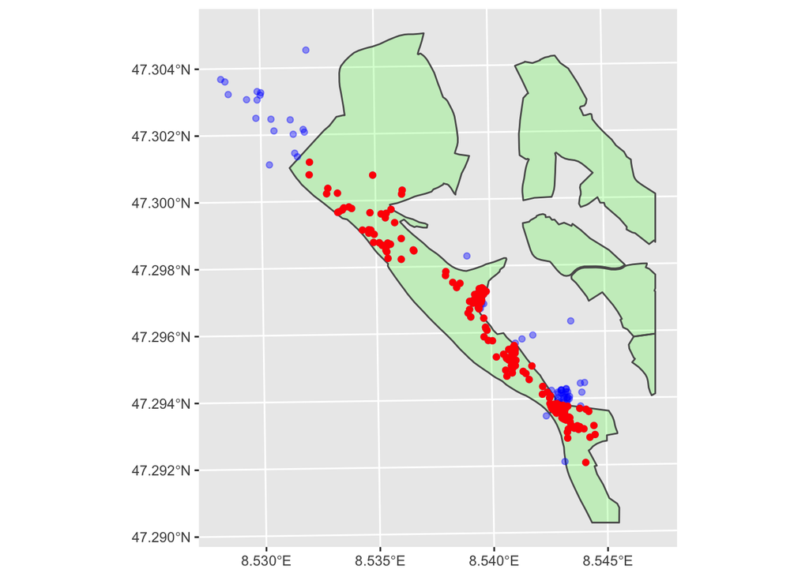

example reh_grafics

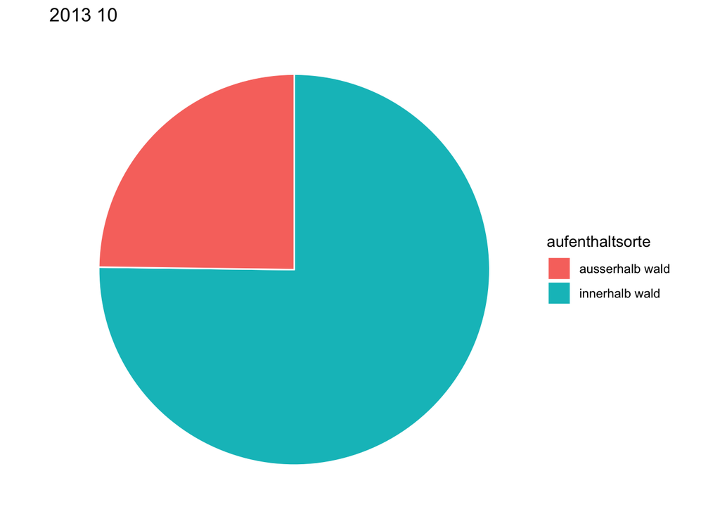

example reh_grafics

```r
reh_grafics("RE02", 2013, 10)
```

Furthermore, the results are required as an output for further analysis. For this, the function is modified to match the requirements.

```r
reh_vector <- function(reh_number, year, month){

  # ein Tier herausfiltern
  reh_number_output <- filter(deer, reh == reh_number)

  # einen Monat filtern
  reh_number_month_output <- reh_number_output %>%
    mutate(year1 = year(datetime_utc),
           month1 = month(datetime_utc)) %>%
    filter(year1 == year, month1 == month)

  # extent begranzen
  reh_number_month_output <- st_as_sf(reh_number_month_output, coords = c("y", "x"), crs = 21781)

  # Herausfinden wie viele Datenpunkte innerhalb Waldfläche und wie viele ausserhalb
  st_agr(sihlwald_21781) = "constant" #this suppresses warning: attribute variables are assumed to be spatially constant throughout all geometries
  intersected_points <- st_intersection(x = sihlwald_21781, y = reh_number_month_output$geometry)

  #vorbereitung daten darstellen
  gesamt <- length(reh_number_month_output$geometry)
  innerhalb_wald <- length(intersected_points$geometry)
  ausserhalb_wald <- gesamt - innerhalb_wald
  aufenthalt <- data.frame(reh = reh_number, year = year, month = month, innerhalb = innerhalb_wald, ausserhalb = ausserhalb_wald)

  # output definieren
  return(aufenthalt)
}
```

Here is an example what the output looks like:

```r
#test function
reh_vector("RE01", 2013, 11)
```

```
##    reh year month innerhalb ausserhalb
## 1 RE01 2013    11       232          7
```

# data preparation for further analysis

In order to analyze all animals, a dataframe with all input combinations must be prepared:

```r
input_data <- deer %>%
  mutate(year = year(datetime_utc),
         month = month(datetime_utc)) %>%
  filter(year == year, month == month) %>%
  transmute(reh = reh, year = year, month = month) %>%
  distinct(reh, year, month)

head(input_data)
```

```
## # A tibble: 6 × 3
##   reh    year month
##   <chr> <dbl> <dbl>
## 1 RE01   2013     9
## 2 RE01   2013    10
## 3 RE01   2013    11
## 4 RE01   2013    12
## 5 RE01   2014     1
## 6 RE01   2014     2
```

# loop

learning how a loop works to create a dataframe whereas the function created before is aplied to all input combinations.

```r
y <- NULL
for(i in 1:length(input_data$reh)){
  result <- reh_vector(input_data$reh[i], input_data$year[i], input_data$month[i])
  y <- rbind(y, result)
}
```

# improve loop

Even though the loop works fine, using the the map function from the purrr library (within tidiverse) is the more sophisticated variant. This no longer needs an empty object.

```r
map(1:2, function(i){
  reh_vector(input_data$reh[i], input_data$year[i], input_data$month[i])
})
```

```
## [[1]]
##    reh year month innerhalb ausserhalb
## 1 RE01 2013     9       138          7
##
## [[2]]
##    reh year month innerhalb ausserhalb
## 1 RE01 2013    10       213         20
```

# improve to get dataframe

In order to get a dataframe as an output, the function pmap_dfr must be used.

```r
data_in_out <- pmap_dfr(input_data, function(reh, year, month){
  reh_vector(reh, year, month)
})
```

# data preparation for results

The resulting data frame can be used to explore behavior of the deers in different months, but also between animals. This is vizualized using ggplot.

For this, input data for the plots is prepared:

```r
avg_month <- data_in_out %>%
  group_by(month) %>%
  summarise(inside_forest = mean(innerhalb), outside_forest = mean(ausserhalb)) %>%
  #mutate(month = month.abb) %>%
  #took this out, because I couldn't manage to order them chronologically with this included
  pivot_longer(inside_forest:outside_forest, names_to = "in_out", values_to = "count")


#some futher failed tries to implement month names rather than their number
#avg_month$month = factor(avg_month$month, levels = month.abb)


avg_deer <- data_in_out %>%
  group_by(reh) %>%
  summarise(inside_forest = mean(innerhalb), outside_forest = mean(ausserhalb)) %>%
  pivot_longer(inside_forest:outside_forest, names_to = "in_out", values_to = "count")
```

# results

Creating the plot for month comparison. The deers then to stay more often in the forest during winter.

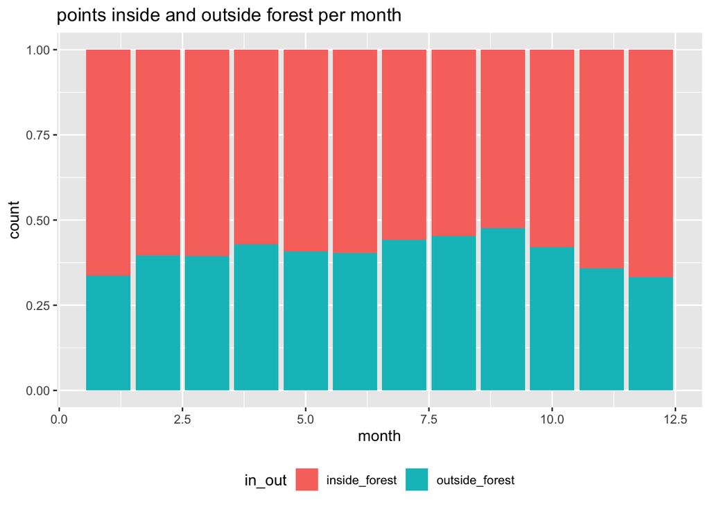

```r
ggplot(avg_month, aes(x = month, y = count, fill = in_out)) +
  geom_bar(stat = "identity", position = "fill") +
  ggtitle("points inside and outside forest per month") +
  theme(legend.position = "bottom")
```

Creating the plot for each animal. There is no pattern visible. However, animal 3, 8, 9 and 14 raises the question if there is anything wrong with the code, since it seems unlilkely that they spend all their time outside of the forest.

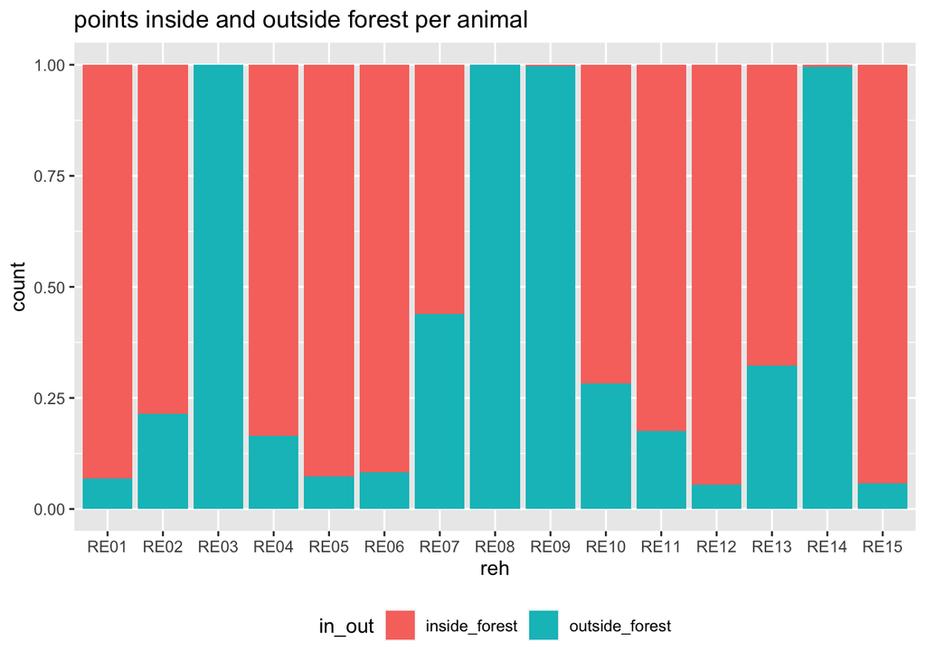

```r
ggplot(avg_deer, aes(x = reh, y = count, fill = in_out)) +
  geom_bar(stat = "identity", position = "fill", width = 0.9) +
  ggtitle("points inside and outside forest per animal") +
  theme(legend.position = "bottom")
```